# **Visualización de datos en R** Primeros pasos con `ggplot2`

# ¡Intenta reproducir un gráfico!

Elige uno de los gráficos siguientes. Con lo que has aprendido de `ggplot2`, intenta escribir el código que reproduce la misma figura. Tienes el nombre del conjunto de datos y la paleta de colores (u otras pistas).

| Nº | Conjunto de datos | Descripción | Pista |
| --- | --- | --- | --- |
| 1 | `Titanic` | Supervivencia de los pasajeros del Titanic | `Titanic` no es un data frame sino una tabla: conviértela con `as.data.frame(Titanic)` y usa la columna `Freq` con `geom_col()`. La paleta de colores es: “#79AEB2”, “#4A6274” |
| 2 | `ToothGrowth` | Efecto de la vitamina C en el crecimiento de los dientes de cobayas | La paleta de colores es: “#58A6A6”, “#EFA355” |
| 3 | `msleep` | Versión actualizada y ampliada del conjunto de datos sobre el sueño de los mamíferos | Puedes colorear en gris los valores NA dentro de la escala de relleno (`na.value = "grey80"`) |
| 4 | `mpg` | Consumo de combustible de 38 modelos de coche populares, de 1999 y 2008 | La paleta de colores es: “#4CC3CD”, “#FEE883” |
| 5 | `midwest` | Datos demográficos del Medio Oeste de EE. UU. | Se combinan dos atributos estéticos dentro de `geom_point()`: el color y el tamaño |
| 6 | `diamonds` | Precios de unos 54.000 diamantes de talla redonda | Se usa la paleta viridis |
| 7 | `HairEyeColor` | Color del pelo y de los ojos de estudiantes de estadística | `HairEyeColor` no es un data frame sino una tabla: conviértela con `as.data.frame(HairEyeColor)` y usa la columna `Freq` con `geom_col()`. La paleta de colores es: “#58A6A6”, “#EFA355” |
| 8 | `infert` | Infertilidad tras un aborto espontáneo o inducido | La paleta de colores es: “#900C3F”, “#C70039”, “#FF5733” |

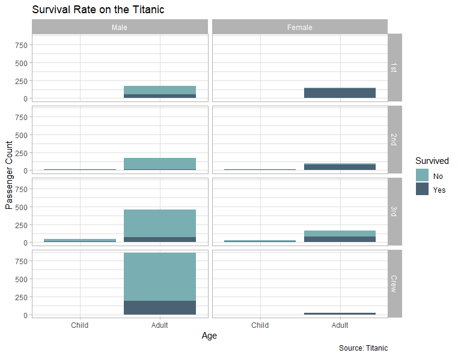

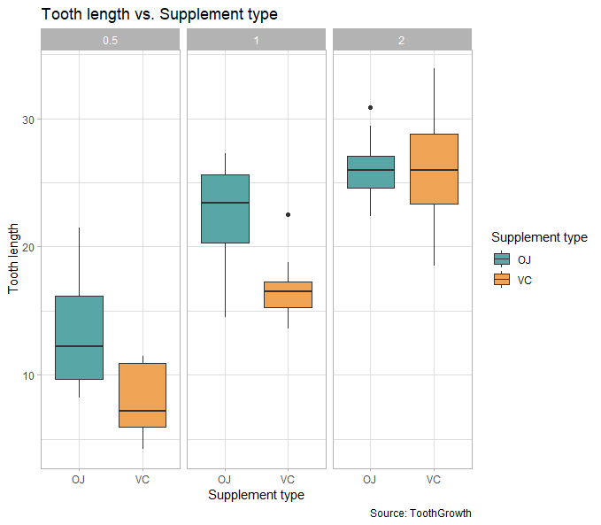

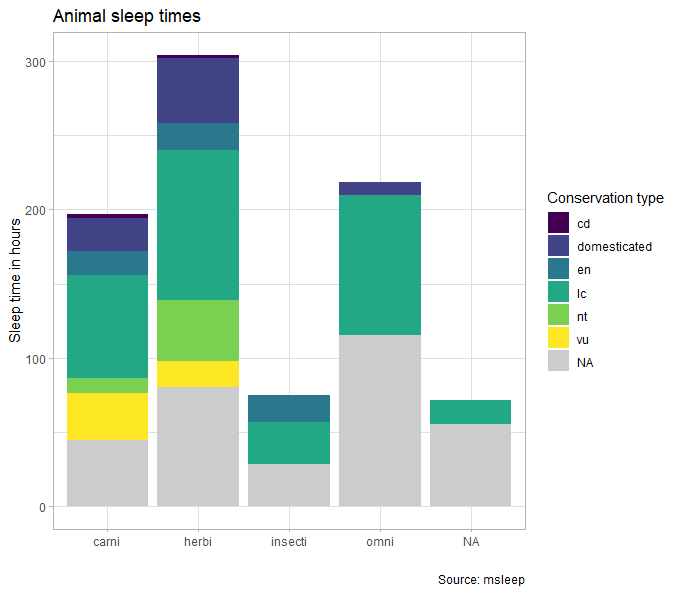

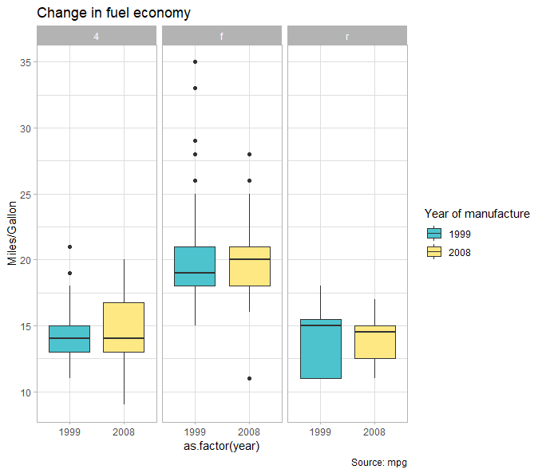

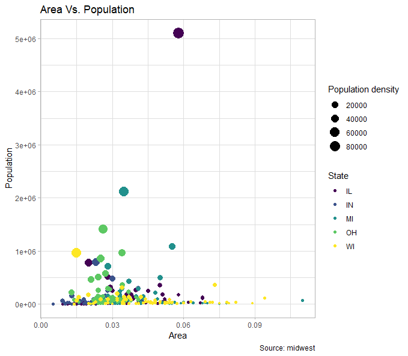

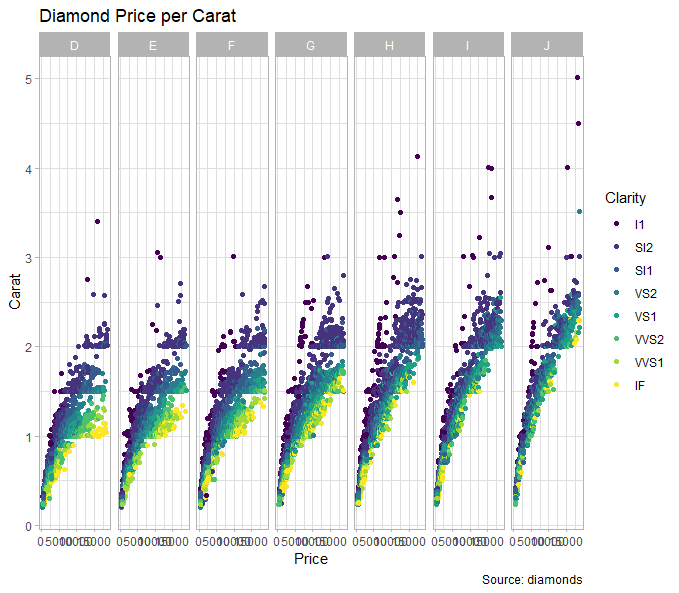

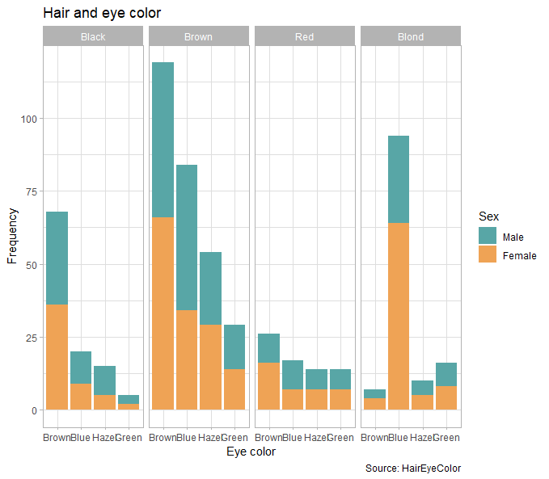

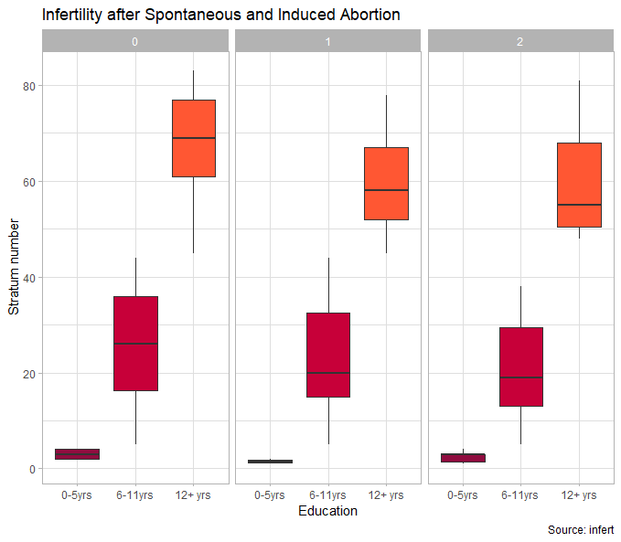

# Analiza datos científicos reales

Para practicar con datos reales, puedes elegir entre 7 conjuntos de datos. Haz una representación de los datos que tenga sentido. Para cada uno tienes el artículo científico correspondiente y una breve descripción que te puede ayudar.

Datos de: Whitlock, Michael C, y Dolph Schluter. 2020. *The Analysis of Biological Data*. Tercera edición.

### 1. El virus del Zika y el tamaño de la cabeza

El virus del Zika se puede transmitir por mosquitos, por vía sexual o de la madre al feto. En 2015 hubo un brote en Brasil que se extendió a otros países de América. En los recién nacidos de madres infectadas se observó con frecuencia un tamaño pequeño de la cabeza (microcefalia), asociado a un desarrollo anormal del cerebro. Estos datos son medidas de la cabeza de fetos de mujeres embarazadas infectadas por el Zika, tomadas por ecografía entre las semanas 33 y 36 de gestación. A esta edad, un tamaño de la cabeza de entre 80 y 94 mm se considera normal en madres no infectadas.

Enlace a los datos: https://raw.githubusercontent.com/marta-coronado/semillero_COBIFMAP/main/semillero2/practica/datos/chap02e2bZikaBiparietalDiameter.csv

- [Lee el estudio](https://www.nejm.org/doi/full/10.1056/nejmoa1602412)

### 2. Vivir a gran altitud

Vivir a gran altitud supone retos fisiológicos por la menor disponibilidad de oxígeno. Las poblaciones humanas de los Andes, Etiopía y el Tíbet se han enfrentado a estos retos y se han adaptado. Un posible mecanismo de adaptación es aumentar el contenido de hemoglobina de la sangre para captar más oxígeno. Beall et al. midieron el contenido de hemoglobina de personas de estas tres poblaciones y de un grupo control de hombres que viven al nivel del mar en EE. UU.

Enlace a los datos: https://raw.githubusercontent.com/marta-coronado/semillero_COBIFMAP/main/semillero2/practica/datos/chap02e3bHumanHemoglobinElevation.csv

- [Lee el estudio](https://www.pnas.org/doi/10.1073/pnas.252649199)

### 3. ¡No vayas hacia la luz!

El estudio encontró que las poblaciones de polillas de zonas urbanas, con décadas de contaminación lumínica, se sienten mucho menos atraídas por la luz que las polillas de zonas sin contaminación lumínica. Esto sugiere una adaptación evolutiva a la luz artificial nocturna.

Enlace a los datos: https://raw.githubusercontent.com/marta-coronado/semillero_COBIFMAP/main/semillero2/practica/datos/chap02q15MothsToLight.csv

- [Lee el estudio](https://royalsocietypublishing.org/doi/10.1098/rsbl.2016.0111)

### 4. Oír colores

Algunas personas perciben uno de sus sentidos a través de otro. Por ejemplo, pueden oír el nombre «Bob» y ver el color gris. Saenz y Koch querían ver cómo influye este tipo de percepción en la capacidad de realizar tareas multisensoriales complejas. Para ello compararon a personas con este tipo de percepción (llamadas sinestésicas) con un grupo de personas sin ella, en una prueba con patrones rítmicos temporales parecidos al código Morse.

Enlace a los datos: https://raw.githubusercontent.com/marta-coronado/semillero_COBIFMAP/main/semillero2/practica/datos/chap02q10Synesthetes.csv

- [Lee el estudio](https://www.sciencedirect.com/science/article/pii/S0960982208007343)

### 5. ¿Comer menos para vivir más?

Por algún motivo, restringir la ingesta de comida suele aumentar la esperanza de vida. Para comprobarlo, Mattison et al. alimentaron a 17 macacos rhesus (7 hembras y 10 machos) con una dieta reducida al 30 % de la nutrición normal, y a otros 17 macacos (8 hembras y 9 machos) con una dieta nutritiva normal.

Enlace a los datos: https://raw.githubusercontent.com/marta-coronado/semillero_COBIFMAP/main/semillero2/practica/datos/chap02q35FoodReductionLifespan.csv

- [Lee el estudio](https://www.nature.com/articles/nature11432)

### 6. ¿Un gen de la monogamia?

El gen del receptor de vasopresina V1a se expresa más en el prosencéfalo de las especies de topillo monógamas que en las promiscuas. Para ver si la expresión de este gen influye en la monogamia, Lim et al. aumentaron experimentalmente la expresión de V1a en el prosencéfalo de 11 machos de topillo de pradera (una especie solitaria y promiscua), y compararon el porcentaje de tiempo que estos machos y los machos control pasaban acurrucados junto a una hembra (como medida de monogamia).

Enlace a los datos: https://raw.githubusercontent.com/marta-coronado/semillero_COBIFMAP/main/semillero2/practica/datos/chap03q15VasopressinVoles.csv

- [Lee el estudio](https://www.nature.com/articles/nature02539)

### 7. Correr con menos peso

Los machos de las arañas del género *Tidarren* son diminutos y pesan alrededor del 1 % de lo que pesan las hembras. Justo antes de la madurez sexual, los machos se amputan voluntariamente uno de sus dos pedipalpos. ¿Podría esto permitirles moverse más rápido?

Enlace a los datos: https://raw.githubusercontent.com/marta-coronado/semillero_COBIFMAP/main/semillero2/practica/datos/chap03e2SpiderAmputation.csv

- [Lee el estudio](https://www.pnas.org/content/101/14/4883)

Pista: los archivos de datos están en la carpeta `datos` que se descomprime con el zip de la práctica, así que puedes leerlos directamente, por ejemplo:

```r
data <- read.csv("datos/chap03e2SpiderAmputation.csv")
```

También puedes leerlos desde el enlace de cada conjunto de datos:

```r
data <- read.csv("https://raw.githubusercontent.com/marta-coronado/semillero_COBIFMAP/main/semillero2/practica/datos/chap03e2SpiderAmputation.csv")
```